# Life history theory

## Learning objectives

1. Understand how and why growth, survival, and fecundity trade off
2. Identify components of a life table
3. Calculate stage-specific mortality/survival

*Review of last lecture: environmental variability and how to deal with that*

*modeled population growth with seed bank*

*more into population structure - why might average something like seed mortality differ between species*

## Population structure

### Terminology

- demography - structured populations
- vital rates - describe each stage *germination, survival to reproduction, fecundity*
- age and stage *related but useful in different circumstances*

*stage examples: seeds, vegetative, reproductive*

### Why care about population structure?

- more realistic *that births and deaths are age/stage structured*

*example: seedlings die in frost, reproductive adults don’t*

- different stages, different pressures *seeds-soil conditions, adults-competition*
- compare individuals within stage

## Tradeoffs

*limited amount of energy and resources - need to decide how to allocate to growth, survival, reproduction*

*most basic tradeoff is the r-K theory*

### r-K

- r species - fast growth *r*, many offspring, low investment
- K species - slow growth, near carrying capacity, few offspring, high investment
- **caveats** - binary instead of spectrum, generalization *example, trees like oaks that are long-lived but produce loads of acorns with low investment per acorn defy this theory*

### Demographic triangle

- growth, stasis, fecundity

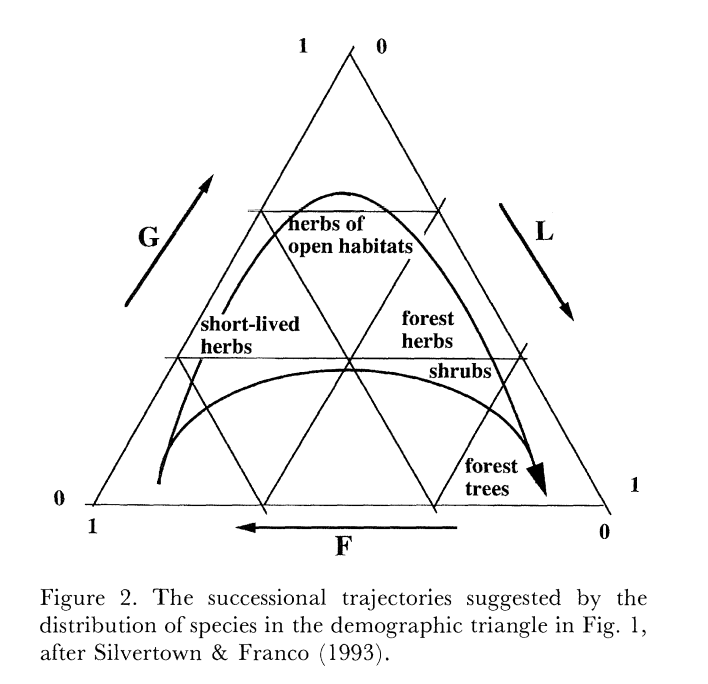

- can’t optimize all three

## Modeling life history stages

- life tables

| Stage | Description | Number Alive (nₓ) | Survival to Next Stage (Pₓ) | Mortality (qₓ) | Fecundity (Fₓ) |
| --- | --- | --- | --- | --- | --- |
| 1 | Seed | 1000 | 0.20 | 0.80 | 0 |
| 2 | Seedling | 200 | 0.25 | 0.75 | 0 |
| 3 | Adult | 50 | — | — | 100 |